```r
source('C:/Users/owenj/OneDrive/Uni/Vacation Scholarship/GEKI_Vacation_Scholarship/src/models/eki_normal_known_var.R')
```

```r
plot_eki_normal_known_var <- function(eki_result, true_params, prior_params) {

  alpha_particles <- eki_result$particles[, 1]
  alpha_sequence <- seq(min(alpha_particles), max(alpha_particles),
                        length.out = 20)
  alpha_prior_density <- dnorm(alpha_sequence, mean = prior_params$alpha.mean,
                               sd = prior_params$alpha.sd)

  true_alpha <- true_params$alpha

  par(mfrow = c(1, 1))

  hist(alpha_particles, freq = F, main = 'Alpha', xlab = '')
  lines(alpha_sequence, alpha_prior_density, col = 'blue')
  abline(v = true_alpha, col = 'red')
}
```

```r
adaptive = TRUE
```

# Results For Multivariate Normal Model

## The Model

We assume that we have access to a single observation from a multivariate normal distribution $y \sim N(\alpha x, 2^2I)$ where $\alpha$ is a scalar and $x$ is a known vector. The unknown parameter in this model is $\alpha$.

In all combinations we draw from the same prior:

- $\alpha \sim ~ N(0, 5^2)$

```r
prior_params <- list(alpha.mean = 0, alpha.sd = 5)
```

## Changing Number of Dimensions

In this experiment I keep $\alpha$ and $\sigma^2$ fixed at 2 and 4 respectively and let $x$ be a vector of 1s corresponding to 10, 50 and 100 dimensions. The purpose of this is to see how the EKI algorithm performs when the number of dimensions increases.

### Standard EKI

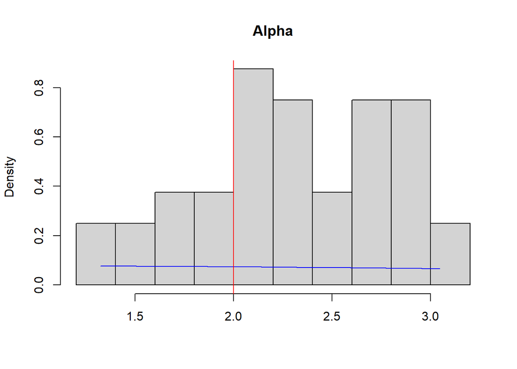

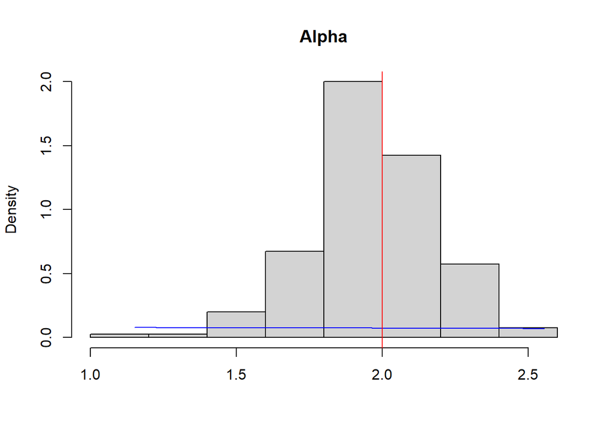

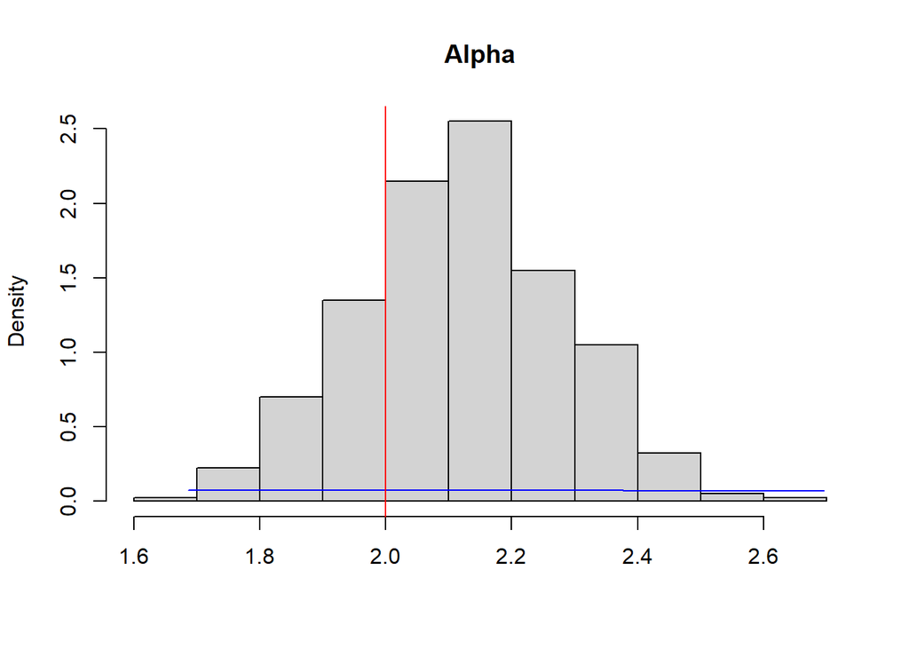

```r
num_dimensions <- c(10, 50, 100)
for (dimension in num_dimensions) {
  num_particles <- 4*dimension
  true_parameters <- list(alpha = 2, sigma = 2, x = rep(1, dimension))
  eki_result <- eki_normal_known_var(num_particles, true_parameters, prior_params,
                                     adaptive = adaptive)
  plot_eki_normal_known_var(eki_result, true_parameters, prior_params)
}
```

## Changing $\alpha$

In this experiment, I keep $\sigma^2$ fixed at 4, make $x$ a 50-dimensional vector of 1s and change $\alpha$ from 0 to 10 in increments of 2. The purpose of this is to make sure that the EKI algorithm is accurate across of range of $\alpha$ and if it changes how the noise parameter is estimated.

```r
alpha_seq <- seq(0, 10, length.out = 6)
```

### Standard EKI

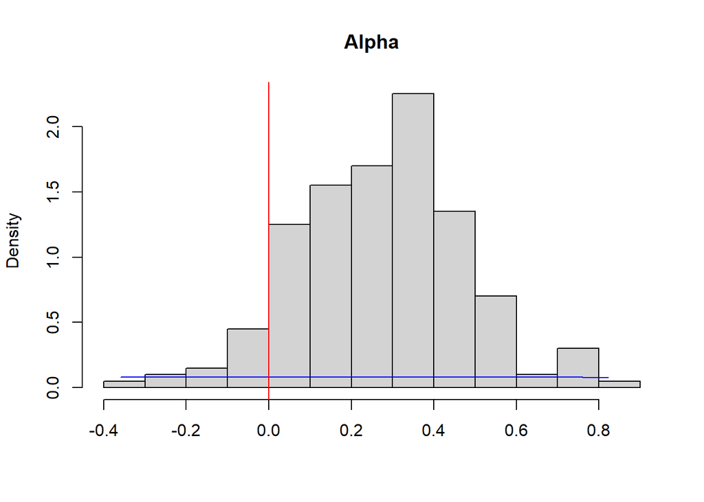

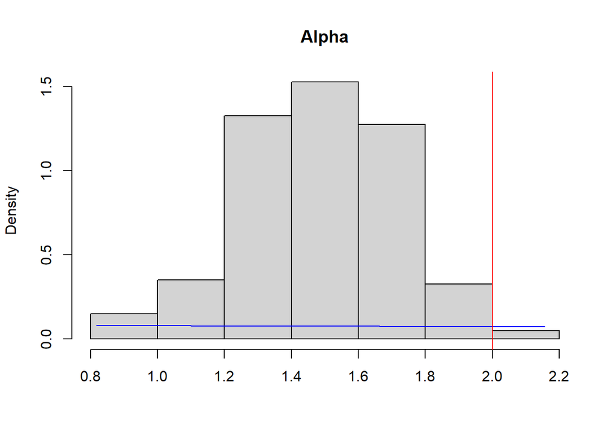

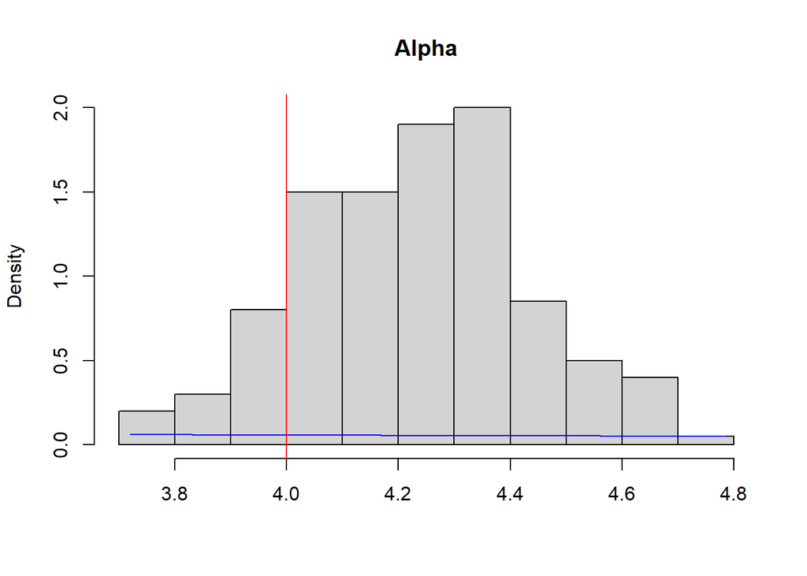

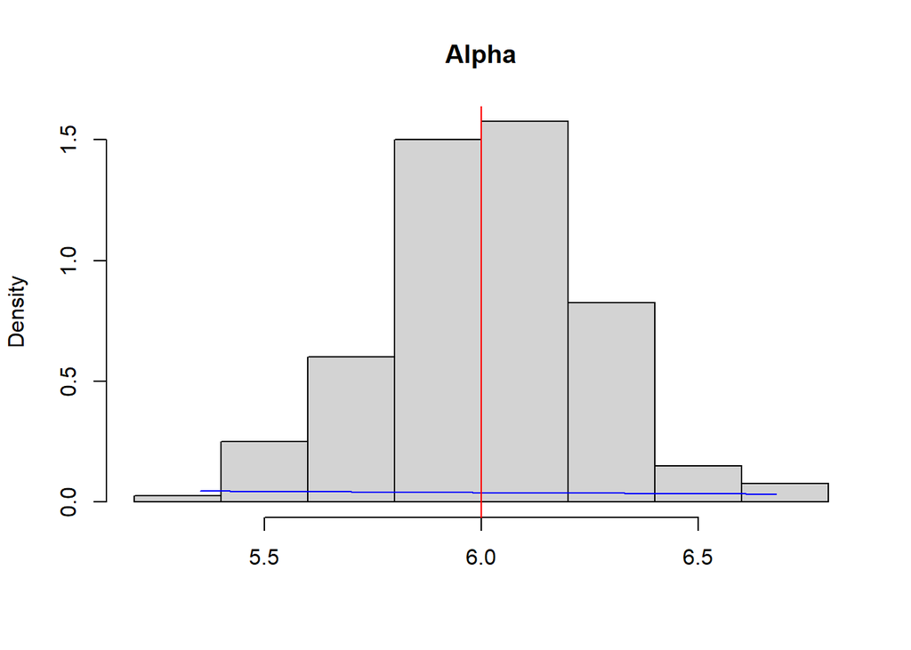

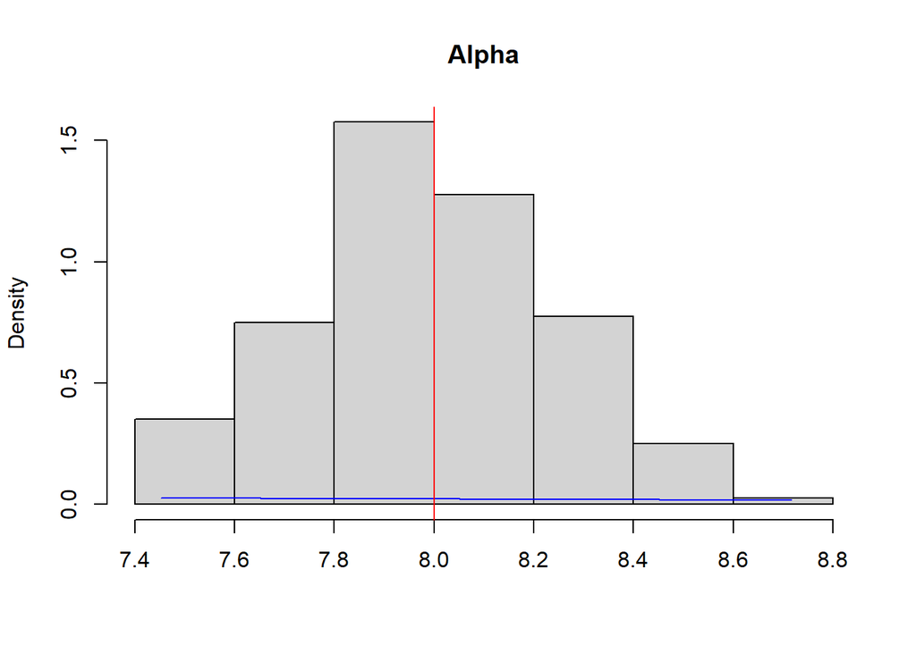

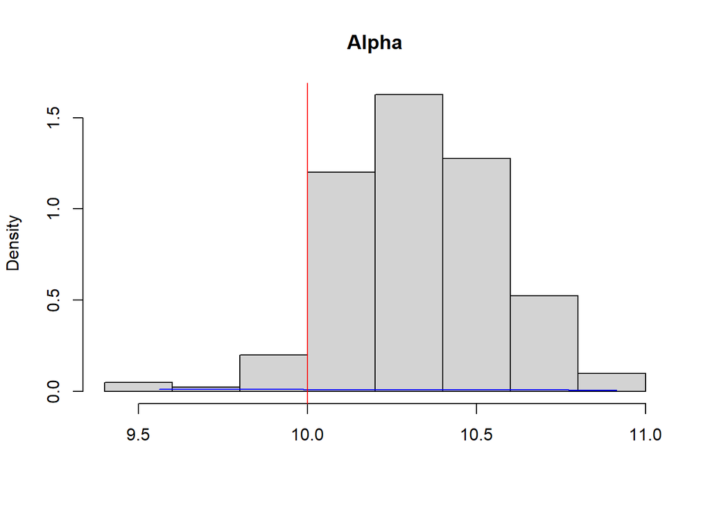

```r
num_dimensions <- 50
num_particles <- 4*num_dimensions
for (alpha in alpha_seq) {

  true_parameters <- list(alpha = alpha, sigma = 2, x = rep(1, num_dimensions))
  eki_result <- eki_normal_known_var(num_particles, true_parameters, prior_params,
                                     adaptive = adaptive)
  plot_eki_normal_known_var(eki_result, true_parameters, prior_params)
}
```

## Changing $\sigma^2$

```r
sigma_seq <- seq(2, 10, length.out = 5)
```

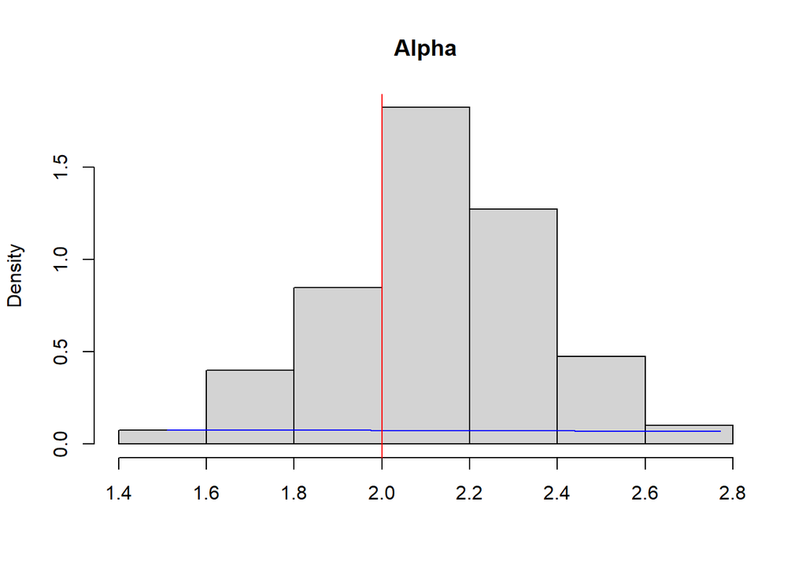

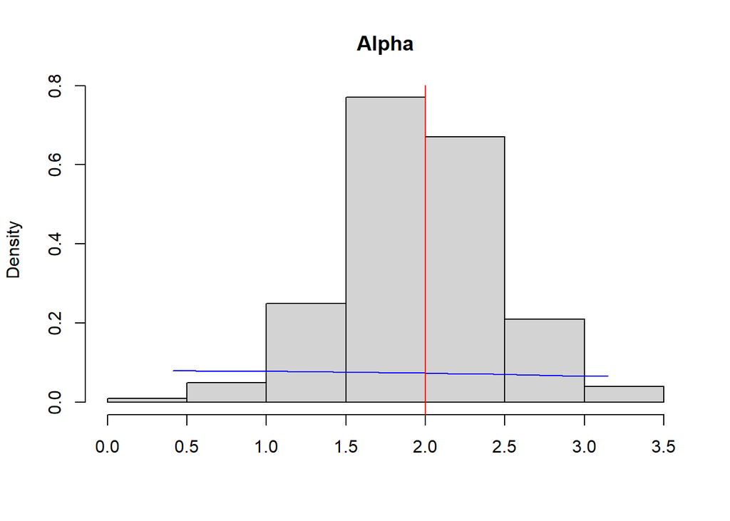

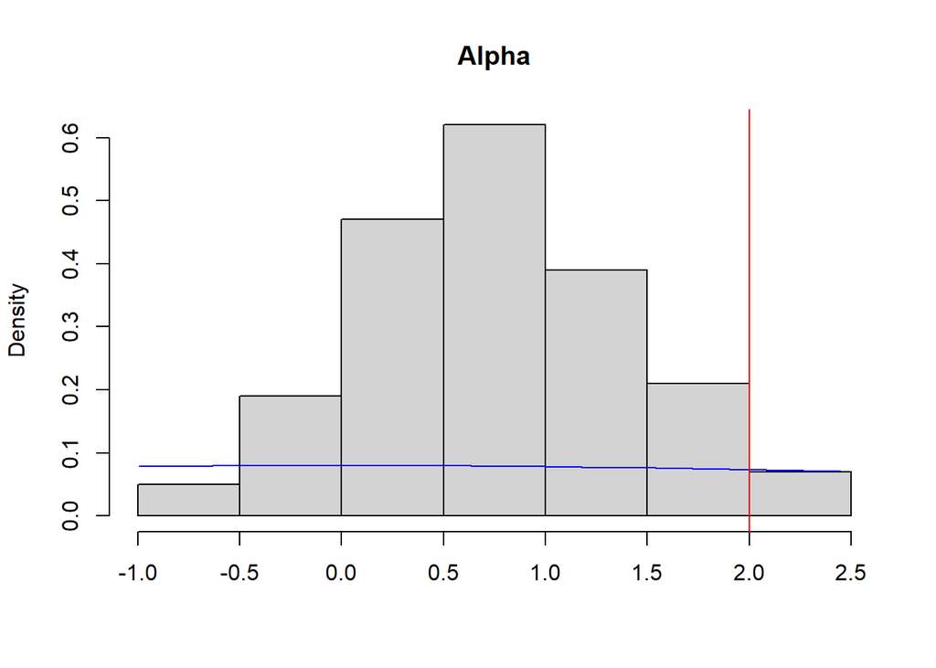

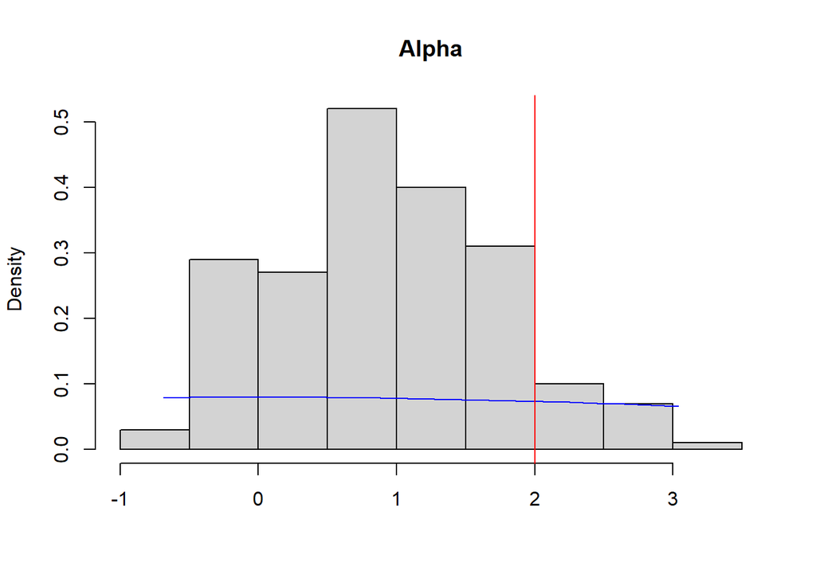

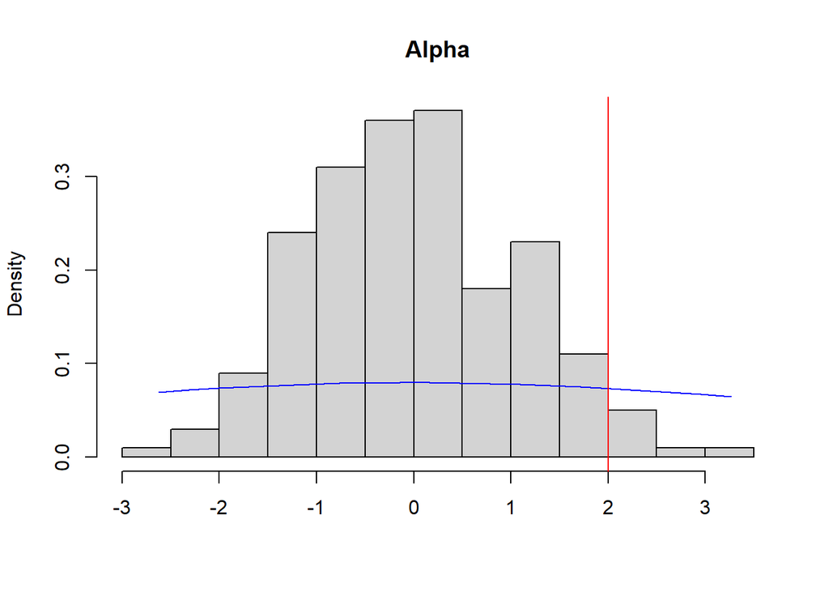

```r
num_dimensions <- 50
num_particles <- 4*num_dimensions
for (sigma in sigma_seq) {

  true_parameters <- list(alpha = 2, sigma = sigma, x = rep(1, num_dimensions))
  eki_result <- eki_normal_known_var(num_particles, true_parameters, prior_params,
                                     adaptive = adaptive)
  plot_eki_normal_known_var(eki_result, true_parameters, prior_params)
}
```

## Changing Number of Particles

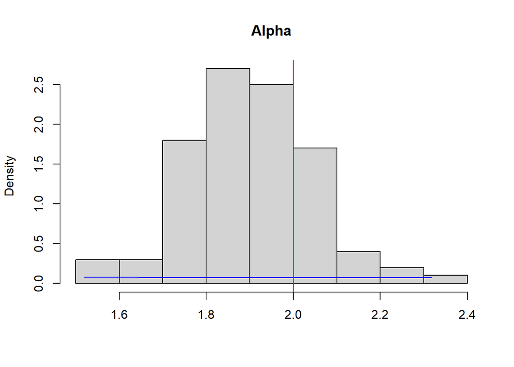

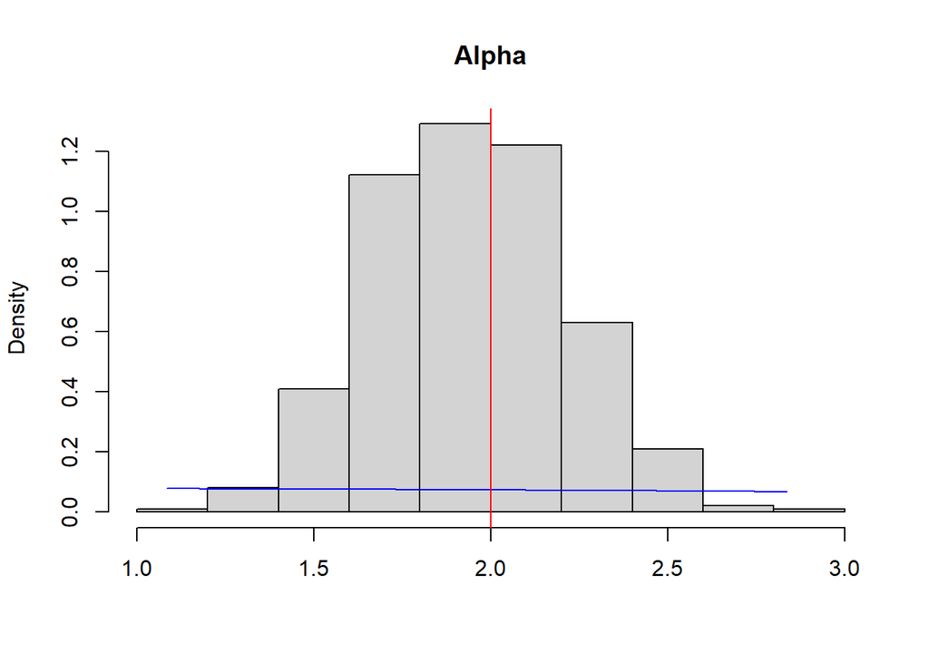

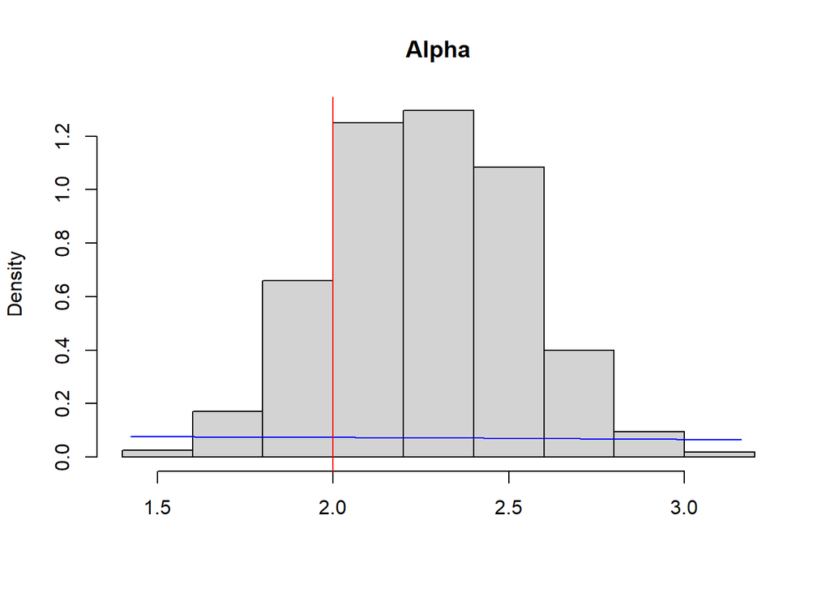

```r
num_dimensions <- 50
particle_seq <- c(100, 500, 1000)
true_parameters <- list(alpha = 2, sigma = 2, x = rep(1, num_dimensions))

for (num_particles in particle_seq) {
  eki_result <- eki_normal_known_var(num_particles, true_parameters, prior_params,
                                     adaptive = adaptive)
  plot_eki_normal_known_var(eki_result, true_parameters, prior_params)
}
```